# Optimal Treatment Analysis

## Outcome Variable

**Outcome Variable:** whz

## Predictor Variables

**Intervention Variable:** mwtkg

**Adjustment Set:**

- arm
- W_mage
- W_fage
- meducyrs
- feducyrs
- single
- brthmon
- delta_W_mage
- delta_W_fage
- delta_meducyrs
- delta_feducyrs
- delta_single
- delta_brthmon

## Stratifying Variables

The analysis was stratified on these variable(s):

- agecat
- studyid
- country

## Data Summary

| agecat | studyid | country | mwtkg | n_cell | n |
| --- | --- | --- | --- | --- | --- |
| Birth | ki0047075b-MAL-ED | BANGLADESH | >=58 kg | 46 | 233 |
| Birth | ki0047075b-MAL-ED | BANGLADESH | <52 kg | 144 | 233 |
| Birth | ki0047075b-MAL-ED | BANGLADESH | [52-58) kg | 43 | 233 |
| Birth | ki0047075b-MAL-ED | BRAZIL | >=58 kg | 117 | 176 |
| Birth | ki0047075b-MAL-ED | BRAZIL | <52 kg | 31 | 176 |
| Birth | ki0047075b-MAL-ED | BRAZIL | [52-58) kg | 28 | 176 |
| Birth | ki0047075b-MAL-ED | INDIA | >=58 kg | 36 | 195 |
| Birth | ki0047075b-MAL-ED | INDIA | <52 kg | 121 | 195 |
| Birth | ki0047075b-MAL-ED | INDIA | [52-58) kg | 38 | 195 |
| Birth | ki0047075b-MAL-ED | NEPAL | >=58 kg | 56 | 167 |
| Birth | ki0047075b-MAL-ED | NEPAL | <52 kg | 48 | 167 |
| Birth | ki0047075b-MAL-ED | NEPAL | [52-58) kg | 63 | 167 |
| Birth | ki0047075b-MAL-ED | PERU | >=58 kg | 97 | 269 |
| Birth | ki0047075b-MAL-ED | PERU | <52 kg | 104 | 269 |
| Birth | ki0047075b-MAL-ED | PERU | [52-58) kg | 68 | 269 |
| Birth | ki0047075b-MAL-ED | SOUTH AFRICA | >=58 kg | 165 | 226 |
| Birth | ki0047075b-MAL-ED | SOUTH AFRICA | <52 kg | 23 | 226 |
| Birth | ki0047075b-MAL-ED | SOUTH AFRICA | [52-58) kg | 38 | 226 |
| Birth | ki0047075b-MAL-ED | TANZANIA, UNITED REPUBLIC OF | >=58 kg | 51 | 116 |
| Birth | ki0047075b-MAL-ED | TANZANIA, UNITED REPUBLIC OF | <52 kg | 37 | 116 |
| Birth | ki0047075b-MAL-ED | TANZANIA, UNITED REPUBLIC OF | [52-58) kg | 28 | 116 |
| Birth | ki1000304b-SAS-CompFeed | INDIA | >=58 kg | 12 | 162 |
| Birth | ki1000304b-SAS-CompFeed | INDIA | <52 kg | 124 | 162 |
| Birth | ki1000304b-SAS-CompFeed | INDIA | [52-58) kg | 26 | 162 |
| Birth | ki1017093-NIH-Birth | BANGLADESH | >=58 kg | 2 | 28 |
| Birth | ki1017093-NIH-Birth | BANGLADESH | <52 kg | 23 | 28 |
| Birth | ki1017093-NIH-Birth | BANGLADESH | [52-58) kg | 3 | 28 |
| Birth | ki1017093c-NIH-Crypto | BANGLADESH | >=58 kg | 4 | 23 |
| Birth | ki1017093c-NIH-Crypto | BANGLADESH | <52 kg | 17 | 23 |
| Birth | ki1017093c-NIH-Crypto | BANGLADESH | [52-58) kg | 2 | 23 |

[output cut: 93 more lines]

The following strata were considered:

- agecat: 24 months, studyid: ki0047075b-MAL-ED, country: BANGLADESH
- agecat: 24 months, studyid: ki0047075b-MAL-ED, country: BRAZIL
- agecat: 24 months, studyid: ki0047075b-MAL-ED, country: INDIA
- agecat: 24 months, studyid: ki0047075b-MAL-ED, country: NEPAL
- agecat: 24 months, studyid: ki0047075b-MAL-ED, country: PERU
- agecat: 24 months, studyid: ki0047075b-MAL-ED, country: SOUTH AFRICA
- agecat: 24 months, studyid: ki0047075b-MAL-ED, country: TANZANIA, UNITED REPUBLIC OF
- agecat: 24 months, studyid: ki1017093-NIH-Birth, country: BANGLADESH
- agecat: 24 months, studyid: ki1017093b-PROVIDE, country: BANGLADESH
- agecat: 24 months, studyid: ki1017093c-NIH-Crypto, country: BANGLADESH
- agecat: 24 months, studyid: ki1066203-TanzaniaChild2, country: TANZANIA, UNITED REPUBLIC OF
- agecat: 24 months, studyid: ki1119695-PROBIT, country: BELARUS
- agecat: 24 months, studyid: ki1126311-ZVITAMBO, country: ZIMBABWE
- agecat: 24 months, studyid: ki1148112-LCNI-5, country: MALAWI
- agecat: 6 months, studyid: ki0047075b-MAL-ED, country: BANGLADESH
- agecat: 6 months, studyid: ki0047075b-MAL-ED, country: BRAZIL
- agecat: 6 months, studyid: ki0047075b-MAL-ED, country: INDIA
- agecat: 6 months, studyid: ki0047075b-MAL-ED, country: NEPAL
- agecat: 6 months, studyid: ki0047075b-MAL-ED, country: PERU
- agecat: 6 months, studyid: ki0047075b-MAL-ED, country: SOUTH AFRICA
- agecat: 6 months, studyid: ki0047075b-MAL-ED, country: TANZANIA, UNITED REPUBLIC OF
- agecat: 6 months, studyid: ki1000304b-SAS-CompFeed, country: INDIA
- agecat: 6 months, studyid: ki1017093-NIH-Birth, country: BANGLADESH
- agecat: 6 months, studyid: ki1017093b-PROVIDE, country: BANGLADESH
- agecat: 6 months, studyid: ki1017093c-NIH-Crypto, country: BANGLADESH
- agecat: 6 months, studyid: ki1066203-TanzaniaChild2, country: TANZANIA, UNITED REPUBLIC OF
- agecat: 6 months, studyid: ki1119695-PROBIT, country: BELARUS
- agecat: 6 months, studyid: ki1126311-ZVITAMBO, country: ZIMBABWE
- agecat: 6 months, studyid: ki1148112-LCNI-5, country: MALAWI
- agecat: Birth, studyid: ki0047075b-MAL-ED, country: BANGLADESH
- agecat: Birth, studyid: ki0047075b-MAL-ED, country: BRAZIL
- agecat: Birth, studyid: ki0047075b-MAL-ED, country: INDIA
- agecat: Birth, studyid: ki0047075b-MAL-ED, country: NEPAL
- agecat: Birth, studyid: ki0047075b-MAL-ED, country: PERU
- agecat: Birth, studyid: ki0047075b-MAL-ED, country: SOUTH AFRICA
- agecat: Birth, studyid: ki0047075b-MAL-ED, country: TANZANIA, UNITED REPUBLIC OF
- agecat: Birth, studyid: ki1000304b-SAS-CompFeed, country: INDIA
- agecat: Birth, studyid: ki1017093-NIH-Birth, country: BANGLADESH
- agecat: Birth, studyid: ki1017093c-NIH-Crypto, country: BANGLADESH
- agecat: Birth, studyid: ki1119695-PROBIT, country: BELARUS
- agecat: Birth, studyid: ki1126311-ZVITAMBO, country: ZIMBABWE

### Dropped Strata

Some strata were dropped due to rare outcomes:

- agecat: Birth, studyid: ki1017093-NIH-Birth, country: BANGLADESH
- agecat: Birth, studyid: ki1017093c-NIH-Crypto, country: BANGLADESH
- agecat: 24 months, studyid: ki1066203-TanzaniaChild2, country: TANZANIA, UNITED REPUBLIC OF

## Methods Detail

We’re interested in the causal parameters $E[Y_a]$ for all values of $a \in \mathcal{A}$. These parameters represent the mean outcome if, possibly contrary to fact, we intervened to set all units to have $A=a$. Under the randomization and positivity assumptions, these are identified by the statistical parameters $\psi_a=E_W[E_{Y|A,W}(Y|A=a,W)]$. In addition, we’re interested in the mean of $Y$, $E[Y]$ under no intervention (the observed mean). We will estimate these parameters by using SuperLearner to fit the relevant likelihood factors – $E_{Y|A,W}(Y|A=a,W)$ and $p(A=a|W)$, and then updating our likelihood fit using a joint TMLE.

For unadjusted analyses ($W=\{\}$), initial likelihoods were estimated using Lrnr_glm to estimate the simple $E(Y|A)$ and Lrnr_mean to estimate $p(A)$. For adjusted analyses, a small library containing Lrnr_glmnet, Lrnr_xgboost, and Lrnr_mean was used.

Having estimated these parameters, we will then use the delta method to estimate relative risks and attributable risks relative to a prespecified baseline level of $A$.

# Results Detail

## Results Plots

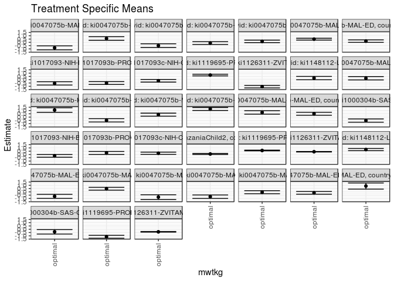

## Results Table

### Parameter: TSM

| agecat | studyid | country | intervention_level | baseline_level | estimate | ci_lower | ci_upper |
| --- | --- | --- | --- | --- | --- | --- | --- |
| Birth | ki0047075b-MAL-ED | BANGLADESH | optimal | observed | -0.6798247 | -0.9816139 | -0.3780355 |
| Birth | ki0047075b-MAL-ED | BRAZIL | optimal | observed | 0.4759024 | 0.2614146 | 0.6903902 |
| Birth | ki0047075b-MAL-ED | INDIA | optimal | observed | -0.7977716 | -1.1544885 | -0.4410547 |
| Birth | ki0047075b-MAL-ED | NEPAL | optimal | observed | -0.7322729 | -0.9927382 | -0.4718075 |
| Birth | ki0047075b-MAL-ED | PERU | optimal | observed | -0.0506458 | -0.2818690 | 0.1805775 |
| Birth | ki0047075b-MAL-ED | SOUTH AFRICA | optimal | observed | -0.1477049 | -0.3530322 | 0.0576224 |
| Birth | ki0047075b-MAL-ED | TANZANIA, UNITED REPUBLIC OF | optimal | observed | 0.8843100 | 0.4185570 | 1.3500629 |
| Birth | ki1000304b-SAS-CompFeed | INDIA | optimal | observed | -0.3896675 | -0.7287322 | -0.0506027 |
| Birth | ki1119695-PROBIT | BELARUS | optimal | observed | -1.1421428 | -1.3604292 | -0.9238563 |
| Birth | ki1126311-ZVITAMBO | ZIMBABWE | optimal | observed | -0.3908156 | -0.4332424 | -0.3483887 |
| 6 months | ki0047075b-MAL-ED | BANGLADESH | optimal | observed | 0.2213672 | -0.0341435 | 0.4768779 |
| 6 months | ki0047075b-MAL-ED | BRAZIL | optimal | observed | 1.0715168 | 0.7253527 | 1.4176809 |
| 6 months | ki0047075b-MAL-ED | INDIA | optimal | observed | -0.4886128 | -0.7436254 | -0.2336002 |
| 6 months | ki0047075b-MAL-ED | NEPAL | optimal | observed | 0.3703391 | 0.1396380 | 0.6010402 |
| 6 months | ki0047075b-MAL-ED | PERU | optimal | observed | 1.2361722 | 1.0110352 | 1.4613092 |
| 6 months | ki0047075b-MAL-ED | SOUTH AFRICA | optimal | observed | 0.7081790 | 0.4474595 | 0.9688986 |
| 6 months | ki0047075b-MAL-ED | TANZANIA, UNITED REPUBLIC OF | optimal | observed | 0.5053056 | 0.2768718 | 0.7337394 |
| 6 months | ki1000304b-SAS-CompFeed | INDIA | optimal | observed | -0.5273353 | -0.7708603 | -0.2838102 |
| 6 months | ki1017093-NIH-Birth | BANGLADESH | optimal | observed | -0.2045527 | -0.4144583 | 0.0053528 |
| 6 months | ki1017093b-PROVIDE | BANGLADESH | optimal | observed | 0.2387199 | 0.0119491 | 0.4654906 |
| 6 months | ki1017093c-NIH-Crypto | BANGLADESH | optimal | observed | 0.1886148 | 0.0228840 | 0.3543455 |
| 6 months | ki1066203-TanzaniaChild2 | TANZANIA, UNITED REPUBLIC OF | optimal | observed | 0.0762631 | 0.0029346 | 0.1495917 |
| 6 months | ki1119695-PROBIT | BELARUS | optimal | observed | 0.6068346 | 0.5491699 | 0.6644992 |
| 6 months | ki1126311-ZVITAMBO | ZIMBABWE | optimal | observed | 0.4165255 | 0.3801495 | 0.4529014 |
| 6 months | ki1148112-LCNI-5 | MALAWI | optimal | observed | 0.7496800 | 0.5801228 | 0.9192372 |
| 24 months | ki0047075b-MAL-ED | BANGLADESH | optimal | observed | -0.8391650 | -1.1380391 | -0.5402910 |
| 24 months | ki0047075b-MAL-ED | BRAZIL | optimal | observed | 0.5856599 | 0.3119938 | 0.8593259 |
| 24 months | ki0047075b-MAL-ED | INDIA | optimal | observed | -0.5042930 | -0.7864328 | -0.2221532 |
| 24 months | ki0047075b-MAL-ED | NEPAL | optimal | observed | -0.1135861 | -0.3265767 | 0.0994045 |
| 24 months | ki0047075b-MAL-ED | PERU | optimal | observed | 0.1448260 | -0.0447516 | 0.3344036 |
| 24 months | ki0047075b-MAL-ED | SOUTH AFRICA | optimal | observed | 0.4807142 | 0.3418539 | 0.6195745 |
| 24 months | ki0047075b-MAL-ED | TANZANIA, UNITED REPUBLIC OF | optimal | observed | 0.1834695 | -0.0076075 | 0.3745465 |
| 24 months | ki1017093-NIH-Birth | BANGLADESH | optimal | observed | -0.5552709 | -0.8084967 | -0.3020451 |
| 24 months | ki1017093b-PROVIDE | BANGLADESH | optimal | observed | -0.5041537 | -0.7240988 | -0.2842086 |
| 24 months | ki1017093c-NIH-Crypto | BANGLADESH | optimal | observed | -0.1586310 | -0.3594433 | 0.0421814 |
| 24 months | ki1119695-PROBIT | BELARUS | optimal | observed | 0.7055808 | 0.5811516 | 0.8300100 |
| 24 months | ki1126311-ZVITAMBO | ZIMBABWE | optimal | observed | -1.0594875 | -1.2498860 | -0.8690890 |
| 24 months | ki1148112-LCNI-5 | MALAWI | optimal | observed | 0.2499495 | -0.0047736 | 0.5046725 |

### Parameter: E(Y)

| agecat | studyid | country | intervention_level | baseline_level | estimate | ci_lower | ci_upper |
| --- | --- | --- | --- | --- | --- | --- | --- |
| Birth | ki0047075b-MAL-ED | BANGLADESH | observed | observed | -0.9724464 | -1.1091046 | -0.8357881 |
| Birth | ki0047075b-MAL-ED | BRAZIL | observed | observed | 0.3832386 | 0.2044597 | 0.5620175 |
| Birth | ki0047075b-MAL-ED | INDIA | observed | observed | -1.0698974 | -1.2115847 | -0.9282102 |
| Birth | ki0047075b-MAL-ED | NEPAL | observed | observed | -0.9126946 | -1.0520834 | -0.7733058 |
| Birth | ki0047075b-MAL-ED | PERU | observed | observed | -0.0660967 | -0.1789362 | 0.0467429 |
| Birth | ki0047075b-MAL-ED | SOUTH AFRICA | observed | observed | -0.0346018 | -0.1831486 | 0.1139451 |
| Birth | ki0047075b-MAL-ED | TANZANIA, UNITED REPUBLIC OF | observed | observed | 0.7950000 | 0.5947353 | 0.9952647 |
| Birth | ki1000304b-SAS-CompFeed | INDIA | observed | observed | -0.2353086 | -0.4984656 | 0.0278483 |
| Birth | ki1119695-PROBIT | BELARUS | observed | observed | -1.1441825 | -1.3547365 | -0.9336286 |
| Birth | ki1126311-ZVITAMBO | ZIMBABWE | observed | observed | -0.4819806 | -0.5108811 | -0.4530800 |
| 6 months | ki0047075b-MAL-ED | BANGLADESH | observed | observed | -0.1397960 | -0.2688682 | -0.0107238 |
| 6 months | ki0047075b-MAL-ED | BRAZIL | observed | observed | 0.9644952 | 0.7999744 | 1.1290160 |
| 6 months | ki0047075b-MAL-ED | INDIA | observed | observed | -0.6987943 | -0.8241325 | -0.5734561 |
| 6 months | ki0047075b-MAL-ED | NEPAL | observed | observed | 0.1110452 | -0.0202712 | 0.2423616 |
| 6 months | ki0047075b-MAL-ED | PERU | observed | observed | 1.0563787 | 0.9342938 | 1.1784635 |
| 6 months | ki0047075b-MAL-ED | SOUTH AFRICA | observed | observed | 0.5290428 | 0.3750394 | 0.6830463 |
| 6 months | ki0047075b-MAL-ED | TANZANIA, UNITED REPUBLIC OF | observed | observed | 0.5170513 | 0.3872178 | 0.6468847 |
| 6 months | ki1000304b-SAS-CompFeed | INDIA | observed | observed | -0.6674586 | -0.8042294 | -0.5306877 |
| 6 months | ki1017093-NIH-Birth | BANGLADESH | observed | observed | -0.4389101 | -0.5279432 | -0.3498771 |
| 6 months | ki1017093b-PROVIDE | BANGLADESH | observed | observed | -0.2079891 | -0.2925599 | -0.1234183 |
| 6 months | ki1017093c-NIH-Crypto | BANGLADESH | observed | observed | 0.0297622 | -0.0491685 | 0.1086930 |
| 6 months | ki1066203-TanzaniaChild2 | TANZANIA, UNITED REPUBLIC OF | observed | observed | 0.0780261 | 0.0247830 | 0.1312691 |
| 6 months | ki1119695-PROBIT | BELARUS | observed | observed | 0.5834072 | 0.5254491 | 0.6413653 |
| 6 months | ki1126311-ZVITAMBO | ZIMBABWE | observed | observed | 0.2953392 | 0.2687669 | 0.3219114 |
| 6 months | ki1148112-LCNI-5 | MALAWI | observed | observed | 0.4518399 | 0.3806212 | 0.5230586 |
| 24 months | ki0047075b-MAL-ED | BANGLADESH | observed | observed | -0.8208255 | -0.9429246 | -0.6987264 |
| 24 months | ki0047075b-MAL-ED | BRAZIL | observed | observed | 0.4282738 | 0.2252365 | 0.6313111 |
| 24 months | ki0047075b-MAL-ED | INDIA | observed | observed | -0.9525664 | -1.0684455 | -0.8366872 |
| 24 months | ki0047075b-MAL-ED | NEPAL | observed | observed | -0.3764474 | -0.4898516 | -0.2630431 |
| 24 months | ki0047075b-MAL-ED | PERU | observed | observed | 0.1199005 | -0.0000331 | 0.2398341 |
| 24 months | ki0047075b-MAL-ED | SOUTH AFRICA | observed | observed | 0.4096154 | 0.2902946 | 0.5289362 |
| 24 months | ki0047075b-MAL-ED | TANZANIA, UNITED REPUBLIC OF | observed | observed | 0.0500935 | -0.0748234 | 0.1750103 |
| 24 months | ki1017093-NIH-Birth | BANGLADESH | observed | observed | -0.9115790 | -1.0095022 | -0.8136559 |
| 24 months | ki1017093b-PROVIDE | BANGLADESH | observed | observed | -0.8864991 | -0.9695215 | -0.8034768 |
| 24 months | ki1017093c-NIH-Crypto | BANGLADESH | observed | observed | -0.6103502 | -0.7050157 | -0.5156847 |
| 24 months | ki1119695-PROBIT | BELARUS | observed | observed | 0.6877387 | 0.5737746 | 0.8017027 |
| 24 months | ki1126311-ZVITAMBO | ZIMBABWE | observed | observed | -1.1865133 | -1.2873598 | -1.0856668 |
| 24 months | ki1148112-LCNI-5 | MALAWI | observed | observed | -0.0467082 | -0.1287046 | 0.0352882 |

### Parameter: PAR

| agecat | studyid | country | intervention_level | baseline_level | estimate | ci_lower | ci_upper |
| --- | --- | --- | --- | --- | --- | --- | --- |
| Birth | ki0047075b-MAL-ED | BANGLADESH | optimal | observed | -0.2926217 | -0.5719885 | -0.0132549 |
| Birth | ki0047075b-MAL-ED | BRAZIL | optimal | observed | -0.0926638 | -0.2189954 | 0.0336678 |
| Birth | ki0047075b-MAL-ED | INDIA | optimal | observed | -0.2721259 | -0.5892275 | 0.0449758 |
| Birth | ki0047075b-MAL-ED | NEPAL | optimal | observed | -0.1804218 | -0.3836529 | 0.0228094 |
| Birth | ki0047075b-MAL-ED | PERU | optimal | observed | -0.0154509 | -0.1996400 | 0.1687382 |
| Birth | ki0047075b-MAL-ED | SOUTH AFRICA | optimal | observed | 0.1131031 | -0.0308742 | 0.2570805 |
| Birth | ki0047075b-MAL-ED | TANZANIA, UNITED REPUBLIC OF | optimal | observed | -0.0893100 | -0.4609220 | 0.2823021 |
| Birth | ki1000304b-SAS-CompFeed | INDIA | optimal | observed | 0.1543588 | -0.2299737 | 0.5386914 |
| Birth | ki1119695-PROBIT | BELARUS | optimal | observed | -0.0020398 | -0.0283920 | 0.0243125 |
| Birth | ki1126311-ZVITAMBO | ZIMBABWE | optimal | observed | -0.0911650 | -0.1214656 | -0.0608644 |
| 6 months | ki0047075b-MAL-ED | BANGLADESH | optimal | observed | -0.3611632 | -0.5993162 | -0.1230102 |
| 6 months | ki0047075b-MAL-ED | BRAZIL | optimal | observed | -0.1070216 | -0.4042468 | 0.1902035 |
| 6 months | ki0047075b-MAL-ED | INDIA | optimal | observed | -0.2101815 | -0.4545121 | 0.0341490 |
| 6 months | ki0047075b-MAL-ED | NEPAL | optimal | observed | -0.2592939 | -0.4460287 | -0.0725591 |
| 6 months | ki0047075b-MAL-ED | PERU | optimal | observed | -0.1797935 | -0.3580496 | -0.0015374 |
| 6 months | ki0047075b-MAL-ED | SOUTH AFRICA | optimal | observed | -0.1791362 | -0.3832578 | 0.0249854 |
| 6 months | ki0047075b-MAL-ED | TANZANIA, UNITED REPUBLIC OF | optimal | observed | 0.0117457 | -0.1892221 | 0.2127134 |
| 6 months | ki1000304b-SAS-CompFeed | INDIA | optimal | observed | -0.1401233 | -0.3268504 | 0.0466038 |
| 6 months | ki1017093-NIH-Birth | BANGLADESH | optimal | observed | -0.2343574 | -0.4366847 | -0.0320301 |
| 6 months | ki1017093b-PROVIDE | BANGLADESH | optimal | observed | -0.4467090 | -0.6508158 | -0.2426022 |
| 6 months | ki1017093c-NIH-Crypto | BANGLADESH | optimal | observed | -0.1588525 | -0.3030126 | -0.0146924 |
| 6 months | ki1066203-TanzaniaChild2 | TANZANIA, UNITED REPUBLIC OF | optimal | observed | 0.0017629 | -0.0474905 | 0.0510163 |
| 6 months | ki1119695-PROBIT | BELARUS | optimal | observed | -0.0234274 | -0.0376356 | -0.0092192 |
| 6 months | ki1126311-ZVITAMBO | ZIMBABWE | optimal | observed | -0.1211863 | -0.1470857 | -0.0952868 |
| 6 months | ki1148112-LCNI-5 | MALAWI | optimal | observed | -0.2978401 | -0.4586803 | -0.1369998 |
| 24 months | ki0047075b-MAL-ED | BANGLADESH | optimal | observed | 0.0183396 | -0.2550721 | 0.2917513 |
| 24 months | ki0047075b-MAL-ED | BRAZIL | optimal | observed | -0.1573860 | -0.3282452 | 0.0134731 |
| 24 months | ki0047075b-MAL-ED | INDIA | optimal | observed | -0.4482734 | -0.7083294 | -0.1882174 |
| 24 months | ki0047075b-MAL-ED | NEPAL | optimal | observed | -0.2628613 | -0.4312370 | -0.0944855 |
| 24 months | ki0047075b-MAL-ED | PERU | optimal | observed | -0.0249255 | -0.2077889 | 0.1579379 |
| 24 months | ki0047075b-MAL-ED | SOUTH AFRICA | optimal | observed | -0.0710988 | -0.1489859 | 0.0067883 |
| 24 months | ki0047075b-MAL-ED | TANZANIA, UNITED REPUBLIC OF | optimal | observed | -0.1333760 | -0.2939465 | 0.0271945 |
| 24 months | ki1017093-NIH-Birth | BANGLADESH | optimal | observed | -0.3563082 | -0.5968293 | -0.1157871 |
| 24 months | ki1017093b-PROVIDE | BANGLADESH | optimal | observed | -0.3823454 | -0.5785787 | -0.1861121 |
| 24 months | ki1017093c-NIH-Crypto | BANGLADESH | optimal | observed | -0.4517192 | -0.6263716 | -0.2770668 |
| 24 months | ki1119695-PROBIT | BELARUS | optimal | observed | -0.0178421 | -0.0630425 | 0.0273582 |
| 24 months | ki1126311-ZVITAMBO | ZIMBABWE | optimal | observed | -0.1270259 | -0.2922943 | 0.0382426 |
| 24 months | ki1148112-LCNI-5 | MALAWI | optimal | observed | -0.2966576 | -0.5331888 | -0.0601265 |